# 3.4 Enrichment Analysis

#### Load R packages and define colour functions

```r
library(tidyverse) ; library(reshape2) ; library(glue) ; library(plotly) ; library(dendextend)
library(RColorBrewer) ; library(viridis) ; require(gridExtra) ; library(colorspace) ; library(corrplot)
library(GGally) ; library(ggpubr) ; library(ggExtra)
library(WGCNA)
library(expss)
library(polycor)
library(biomaRt)
library(clusterProfiler) ; library(ReactomePA) ; library(DOSE) ; library(org.Hs.eg.db)
library(foreach) ; library(doParallel)
library(knitr) ; library(kableExtra) ; library(xtable)

SFARI_colour_hue = function(r) {
  pal = c('#FF7631','#FFB100','#E8E328','#8CC83F','#62CCA6','#59B9C9','#b3b3b3','#808080','gray','#d9d9d9')[r]
}

# Get colors from the ggplot palette
gg_colour_hue = function(n) {
  hues = seq(15, 375, length = n+1)
  pal = hcl(h = hues, l = 65, c = 100)[1:n]
}

# Assign an HCL rainbow colour to each module
get_mod_colours = function(mods){

  n = length(unique(mods))-1
  set.seed(123) ; rand_order = sample(1:n)
  mod_colors = c('white', gg_colour_hue(n)[rand_order])
  names(mod_colors) = mods %>% table %>% names

  return(mod_colors)
}

# Compare results from GSEA and ORA
compare_methods = function(GSEA_list, ORA_list, top_modules_enrichment, top_modules, database){

  for(module in top_modules){
    cat(paste0('  \n  \n Enrichment results for cluster ',
                 genes_info$module_number[genes_info$Module==module][1], ':  \n'))

    cat(paste0('- GSEA has ', nrow(GSEA_list[[module]][[database]]@result), ' enriched term(s)  \n'))
    cat(paste0('- ORA has  ', nrow(ORA_list[[module]][[database]]@result), ' enriched term(s)  \n'))
    cat(paste0('- ', nrow(top_modules_enrichment[[module]][[database]]),
               ' terms are enriched in both methods  \n  \n'))

    enriched_terms = top_modules_enrichment[[module]][[database]] %>%
                     dplyr::select(ID, Description.x, p.adjust_ORA, p.adjust_GSEA, qvalue_ORA, GeneRatio) %>%
                     dplyr::rename('Description' = Description.x)

    if(nrow(enriched_terms)>0){
      print(enriched_terms %>% mutate(pval_mean = p.adjust_ORA + p.adjust_GSEA) %>%
                          arrange(pval_mean) %>% dplyr::select(-pval_mean) %>%
            kable %>% kable_styling(full_width = F))

      ##########################################################################################################
      # Get genes involved
      genes = c()
      i=1
      for(row_genes in top_modules_enrichment[[module]][[database]] %>% pull(geneID)){
        genes = c(genes, strsplit(row_genes,'/') %>% unlist) %>% unique
        if(i==5){
          cat(paste0('Genes involved in top 5 enriched terms: ',
                     paste(gene_names %>% filter(entrezgene %in% genes) %>% pull(hgnc_symbol) %>% unique %>%
                           sort, collapse = ', '),'\n'))
        }
        i = i+1
      }

      if(i != 5){
        genes = gene_names %>% filter(entrezgene %in% genes) %>% pull(hgnc_symbol) %>% unique %>% sort
        cat(paste0('\nGenes involved in all enriched terms: ', paste(genes, collapse = ', ')))
      }
      ##########################################################################################################
    }

  }
}

plot_results = function(top_modules_enrichment, top_modules, database){

  l = htmltools::tagList()

  for(i in 1:length(top_modules)){

    plot_data = top_modules_enrichment[[top_modules[i]]][[database]] %>%
                dplyr::rename('Description' = Description.x)

    if(nrow(plot_data)>5){
      min_val = min(min(plot_data$p.adjust_GSEA), min(plot_data$p.adjust_ORA))
      max_val = max(max(max(plot_data$p.adjust_GSEA), max(plot_data$p.adjust_ORA)), 0.05)
      ggp = ggplotly(plot_data %>% ggplot(aes(p.adjust_GSEA, p.adjust_ORA, color = NES)) +
                     geom_point(aes(id = Description)) +
                     geom_vline(xintercept = 0.05, color = 'gray', linetype = 'dotted') +
                     geom_hline(yintercept = 0.05, color = 'gray', linetype = 'dotted') +
                     ggtitle(paste0('Enriched terms in common for cluster ',
                                    genes_info$module_number[genes_info$Module==top_modules[i]][1])) +
                     scale_x_continuous(limits = c(min_val, max_val)) +
                     scale_y_continuous(limits = c(min_val, max_val)) +
                     xlab('Corrected p-value for GSEA') + ylab('Corrected p-value for ORA') +
                     scale_colour_viridis(direction = -1) + theme_minimal() + coord_fixed())
      l[[i]] = ggp
    }
  }

  return(l)
}


# plot_shared_genes(top_modules_enrichment, top_modules, 'GO')
plot_shared_genes = function(top_modules_enrichment, top_modules, database){

  for(tm in 1:length(top_modules)){

    plot_data = top_modules_enrichment[[top_modules[tm]]][[database]] %>%
                mutate(pval_mean = p.adjust_ORA + p.adjust_GSEA) %>% arrange(pval_mean) %>%
                dplyr::select(ID, geneID)

    if(nrow(plot_data)>=2){

      plot_data = plot_data %>% slice_head(n=5)

      shared_genes = matrix(0, nrow(plot_data), nrow(plot_data))
      for(i in 1:(nrow(plot_data)-1)){
        for(j in (i+1):nrow(plot_data)){
          gene_set_1 = strsplit(plot_data$geneID[i], '/') %>% unlist
          gene_set_2 = strsplit(plot_data$geneID[j], '/') %>% unlist
          shared_genes[i,j] = sum(gene_set_1 %in% gene_set_2)/length(unique(c(gene_set_1, gene_set_2)))
          shared_genes[j,i] = shared_genes[i,j]
        }
      }
      rownames(shared_genes) = plot_data$ID
      colnames(shared_genes) = plot_data$ID

      corrplot(shared_genes, type = 'lower', method = 'square', diag = FALSE, number.digits = 2, cl.pos = 'n',
               tl.pos = 'ld', tl.col = '#666666', order = 'hclust', col.lim = c(0,1), addCoef.col = 'black',
               mar = c(0,0,2,0), tl.cex = 0.8, number.cex= 0.8,
               title = paste0('Genes in common for top terms in cluster ',
                              genes_info$module_number[genes_info$Module==top_modules[tm]][1]))
    }
  }
}

# Print table with top results (for annex in thesis)
print_table_w_top_results = function(top_modules_enrichment, module, database, n){

  enriched_terms = top_modules_enrichment[[module]][[database]] %>%
                   mutate(pval_mean = p.adjust_ORA + p.adjust_GSEA) %>% arrange(pval_mean) %>%
                   top_n(-n, wt=pval_mean) %>% dplyr::rename('Description' = Description.x) %>%
                   dplyr::select(ID, Description, p.adjust_GSEA, p.adjust_ORA, NES, GeneRatio) %>%
                   xtable(display =c('s','s','s','e','e','f','s'))

  return(print(enriched_terms, include.rownames=FALSE))
}

#print_table_w_top_results(selected_modules_enrichment, names(selected_modules_enrichment)[2], 'DN', 5)
```

#### Load preprocessed dataset (code in 2.1.Preprocessing_pipeline.Rmd)

```r
# SFARI Genes
SFARI_genes = read_csv('./../../SFARI/Data/SFARI_genes_01-03-2020_w_ensembl_IDs.csv')

# Load Gandal dataset
load('./../Data/preprocessedData/preprocessed_data.RData')
datExpr = datExpr %>% data.frame

# WGCNA metrics
WGCNA_metrics = read.csv('./../Data/preprocessedData/WGCNA_metrics.csv')

# Updates genes_info with SFARI information and clusters
genes_info = genes_info %>% left_join(SFARI_genes, by = 'ID') %>%
             left_join(datGenes %>% mutate(ID = ensembl_gene_id) %>% dplyr::select(ID, hgnc_symbol), by = 'ID') %>%
             dplyr::select(ID, hgnc_symbol, log2FoldChange, shrunken_log2FoldChange, significant, Neuronal) %>%
             left_join(WGCNA_metrics, by = 'ID') %>% dplyr::select(-contains('pval'))


################################################################################################################
# Get entrezene ID of genes
gene_names = genes_info %>% dplyr::rename('ensembl_gene_id' = ID) %>% filter(Module!='gray')

# ClusterProfile works with Entrez Gene Ids, o we have to assign one to each gene
getinfo = c('ensembl_gene_id','entrezgene')
mart=useMart(biomart='ENSEMBL_MART_ENSEMBL',dataset='hsapiens_gene_ensembl',host='feb2014.archive.ensembl.org')
biomart_output = getBM(attributes=getinfo, filters=c('ensembl_gene_id'),
                       values=gene_names$ensembl_gene_id, mart=mart)

gene_names = biomart_output %>% left_join(gene_names %>% dplyr::select(ensembl_gene_id, hgnc_symbol),
                                          by='ensembl_gene_id') %>% dplyr::rename('ID'=ensembl_gene_id)

rm(getinfo, mart, biomart_output)



rm(dds, WGCNA_metrics)
```

## Methodology

Both GSEA and ORA are commonly used to study enrichment in sets of genes, but when using them for studying our modules both have shortcomings:

- **GSEA** takes into consideration some ordering of the genes, in this case given by their Module Membership, which is correlated to the membership of genes to the module, but has two problems:
  - Being a continuous scale, it doesn’t separate by a threshold the genes that are truly in the cluster from the rest
  - The Module Membership metric is correlated to the real membership of the module, but this correlation is not perfect: a high MM doesn’t always mean the gene belongs to that module, for example, selecting a random module, in the plot below we can see the MM distribution of genes belonging to that module against the rest of the genes belonging to other modules and, although in general, genes belonging to that module have a higher distribution of MM, there is still a big overlap between the two groups, making MM a noisy metric for performing GSEA

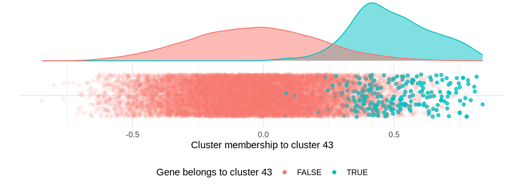

```r
module = genes_info %>% filter(abs(MTcor) > 0.7) %>% slice_head(n=1) %>% pull(Module) %>% as.character

plot_data = genes_info %>% dplyr::select(Module, paste0('MM.',gsub('#','',module))) %>%
            mutate(in_module = substring(Module,2) == gsub('#','',module),
                   selected_module = paste('Cluster', genes_info$module_number[genes_info$Module==module][1] %>%
                                             as.character)) %>%
            mutate(alpha = ifelse(in_module, 0.8, 0.1))
colnames(plot_data)[2] = 'MM'

p = plot_data %>% ggplot(aes(selected_module, MM, color = in_module)) + geom_jitter(alpha = plot_data$alpha) +
    xlab('') + ylab(paste('Cluster membership to cluster',
                          genes_info$module_number[genes_info$Module==module][1])) + coord_flip() +
    theme_minimal() + theme(legend.position = 'bottom', axis.text.y = element_blank(),
                            axis.ticks.y = element_blank()) +
    labs(color = paste('Gene belongs to cluster', genes_info$module_number[genes_info$Module==module][1]))

ggExtra::ggMarginal(p, type = 'density', groupColour = TRUE, groupFill = TRUE, margins = 'x', size=1)
```

```r
rm(modules, module, p, plot_data)
```

- **ORA** doesn’t rank the genes within the cluster, but considers them all together, so if you have an enrichment only in the most important genes in the module, it will probably be diluted by the rest of the not so important genes and ORA won’t be able to identify it

So perhaps it could be useful to use both methods together, since they seem to complement each other’s shortcomings very well, performing the enrichment using both methods and identifying the terms that are found to be enriched by both

**Note:** Since the enrichment in both methods is quite a stric restriction, we decide to relax the corrected p-value threshold (using Bonferroni correction) to 0.1.

### Perform Enrichment Analysis

**Note:** This script may take a bit to run (~30 mins with an 8 core Intel(R) Core(TM) i5-8400H CPU @ 2.50GHz laptop) and sometimes there are problems with the API and it will freeze or kill the process printing ‘error writing to connection’, but this when this has happened, it has been fixed in less than a day (except once that took 4 days…).

```r
# Modules: 37, 49, 28, 35, 57, 70
top_modules = c('#4A9FFF','#9AA800','#00C0B4','#32B600','#BA9E00','#DF8B00')

if(file.exists('./../Data/preprocessedData/top_modules_enrichment.RData')){
  load('./../Data/preprocessedData/top_modules_enrichment.RData')
  load('./../Data/preprocessedData/GSEA_results.RData')
  load('./../Data/preprocessedData/ORA_results.RData')
} else{

  ################################################################################################################
  # Prepare dataset for Enrichment Analysis

  EA_dataset = genes_info %>% dplyr::rename('ensembl_gene_id' = ID) %>% filter(Module!='gray')

  # ClusterProfile works with Entrez Gene Ids, o we have to assign one to each gene
  getinfo = c('ensembl_gene_id','entrezgene')
  mart=useMart(biomart='ENSEMBL_MART_ENSEMBL',dataset='hsapiens_gene_ensembl',host='feb2014.archive.ensembl.org')
  biomart_output = getBM(attributes=getinfo, filters=c('ensembl_gene_id'),
                         values=EA_dataset$ensembl_gene_id, mart=mart)

  EA_dataset = biomart_output %>% left_join(EA_dataset, by='ensembl_gene_id') %>% dplyr::rename('ID'=ensembl_gene_id)

  rm(getinfo, mart, biomart_output)

  ################################################################################################################
  # GSEA enrichment

  file_name = './../Data/preprocessedData/GSEA_results.RData'
  if(file.exists(file_name)){
    load(file_name)
  } else {
    nPerm = 1e5
    GSEA_dataset = EA_dataset %>% dplyr::select(ID, entrezgene, contains('MM.'))
    GSEA_enrichment = list()

    for(module in top_modules){

      cat(paste0('\nModule: ', which(top_modules == module), '/', length(top_modules)))

      geneList = GSEA_dataset %>% pull(paste0('MM.',substring(module,2)))
      names(geneList) = GSEA_dataset %>% pull(entrezgene) %>% as.character
      geneList = sort(geneList, decreasing = TRUE)

      GSEA_GO = gseGO(geneList, OrgDb = org.Hs.eg.db, pAdjustMethod = 'bonferroni', pvalueCutoff = 0.1,
                      nPerm = nPerm, verbose = FALSE, seed = TRUE)

      GSEA_DO = gseDO(geneList, pAdjustMethod = 'bonferroni', pvalueCutoff = 0.1,
                      nPerm = nPerm, verbose = FALSE, seed = TRUE)

      GSEA_DGN = gseDGN(geneList, pAdjustMethod = 'bonferroni', pvalueCutoff = 0.1,
                        nPerm = nPerm, verbose = FALSE, seed = TRUE)

      GSEA_KEGG = gseKEGG(geneList, organism = 'human', pAdjustMethod = 'bonferroni', pvalueCutoff = 0.1,
                          nPerm = nPerm, verbose = FALSE, seed = TRUE)

      GSEA_Reactome = gsePathway(geneList, organism = 'human', pAdjustMethod = 'bonferroni', pvalueCutoff = 0.1,
                                 nPerm = nPerm, verbose = FALSE, seed = TRUE)

      GSEA_enrichment[[module]] = list('GO' = GSEA_GO, 'DO' = GSEA_DO, 'DGN' = GSEA_DGN, 'KEGG' = GSEA_KEGG,
                                       'Reactome' = GSEA_Reactome)

      # Save after each iteration (in case it breaks)
      save(GSEA_enrichment, file = file_name)
    }

    rm(GSEA_dataset, nPerm, geneList, GSEA_GO, GSEA_DO, GSEA_DGN, GSEA_KEGG, GSEA_Reactome)

  }

  ################################################################################################################
  # ORA enrichment

  file_name = './../Data/preprocessedData/ORA_results.RData'
  if(file.exists(file_name)){
    load(file_name)
  } else {
    # Prepare input
    universe = EA_dataset$entrezgene %>% as.character

    # Perform Enrichment
    ORA_enrichment = list()

    for(module in top_modules){

      genes_in_module = EA_dataset %>% filter(Module == module) %>% pull(entrezgene)

      ORA_GO = enrichGO(gene = genes_in_module, universe = universe, OrgDb = org.Hs.eg.db, ont = 'All',
                        pAdjustMethod = 'bonferroni', pvalueCutoff = 0.1, qvalueCutoff = 1)

      ORA_DO = enrichDO(gene = genes_in_module, universe = universe, qvalueCutoff = 1,
                        pAdjustMethod = 'bonferroni', pvalueCutoff = 0.1)

      ORA_DGN = enrichDGN(gene = genes_in_module, universe = universe, qvalueCutoff = 1,
                          pAdjustMethod = 'bonferroni', pvalueCutoff = 0.1)

      ORA_KEGG = enrichKEGG(gene = genes_in_module, universe = universe, qvalueCutoff = 1,
                            pAdjustMethod = 'bonferroni', pvalueCutoff = 0.1)

      ORA_Reactome = enrichPathway(gene = genes_in_module, universe = universe, qvalueCutoff = 1,
                                   pAdjustMethod = 'bonferroni', pvalueCutoff = 0.1)

      ORA_enrichment[[module]] = list('GO' = ORA_GO, 'DO' = ORA_DO, 'DGN' = ORA_DGN, 'KEGG' = ORA_KEGG,
                                      'Reactome' = ORA_Reactome)

      # Save after each iteration
      save(ORA_enrichment, file = file_name)
    }

    rm(universe, genes_in_module, module, ORA_GO, ORA_DGN, ORA_DO, ORA_KEGG, ORA_Reactome)

  }

  ################################################################################################################
  # Get shared enrichment for each module

  top_modules_enrichment = list()

  for(module in top_modules){

    module_enrichment = list()
    GSEA_enrichment_for_module = GSEA_enrichment[[module]]
    ORA_enrichment_for_module = ORA_enrichment[[module]]

    for(dataset in c('KEGG', 'Reactome', 'GO', 'DO', 'DGN')){

      GSEA_enrichment_dataset = GSEA_enrichment_for_module[[dataset]] %>% data.frame %>%
        dplyr::rename('pvalue_GSEA' = pvalue, 'p.adjust_GSEA' = p.adjust, 'qvalues_GSEA' = qvalues)

      ORA_enrichment_dataset = ORA_enrichment_for_module[[dataset]] %>% data.frame %>%
        dplyr::rename('pvalue_ORA' = pvalue, 'p.adjust_ORA' = p.adjust, 'qvalue_ORA' = qvalue)

      # Get shared enrichments (if any)
      shared_enrichment_dataset = GSEA_enrichment_dataset %>% inner_join(ORA_enrichment_dataset, by = 'ID')

      module_enrichment[[dataset]] = shared_enrichment_dataset
    }

    top_modules_enrichment[[module]] = module_enrichment
  }

  save(top_modules_enrichment, file = './../Data/preprocessedData/top_modules_enrichment.RData')

  rm(module, module_enrichment, GSEA_enrichment_for_module, ORA_enrichment_for_module, dataset,
     GSEA_enrichment_dataset, ORA_enrichment_dataset, shared_enrichment_dataset)
}
```

# 3.4.1 Top clusters by cluster-diagnosis correlation

Neither cluster is enriched in any of the databases

```r
top_modules_mtcor = top_modules[1:2]
```

### Gene Ontology

```r
compare_methods(GSEA_enrichment, ORA_enrichment, top_modules_enrichment, top_modules_mtcor, 'GO')
```

Enrichment results for cluster 37:  
- GSEA has 33 enriched term(s)  
- ORA has 0 enriched term(s)  
- 0 terms are enriched in both methods

Enrichment results for cluster 49:  
- GSEA has 26 enriched term(s)  
- ORA has 0 enriched term(s)  
- 0 terms are enriched in both methods

### Disease Ontology

```r
compare_methods(GSEA_enrichment, ORA_enrichment, top_modules_enrichment, top_modules_mtcor, 'DO')
```

Enrichment results for cluster 37:  
- GSEA has 0 enriched term(s)  
- ORA has 211 enriched term(s)  
- 0 terms are enriched in both methods

Enrichment results for cluster 49:  
- GSEA has 0 enriched term(s)  
- ORA has 103 enriched term(s)  
- 0 terms are enriched in both methods

### Disease Gene Network

```r
compare_methods(GSEA_enrichment, ORA_enrichment, top_modules_enrichment, top_modules_mtcor, 'DGN')
```

Enrichment results for cluster 37:  
- GSEA has 2 enriched term(s)  
- ORA has 602 enriched term(s)  
- 0 terms are enriched in both methods

Enrichment results for cluster 49:  
- GSEA has 3 enriched term(s)  
- ORA has 476 enriched term(s)  
- 0 terms are enriched in both methods

### KEGG

```r
compare_methods(GSEA_enrichment, ORA_enrichment, top_modules_enrichment, top_modules_mtcor, 'KEGG')
```

Enrichment results for cluster 37:  
- GSEA has 14 enriched term(s)  
- ORA has 86 enriched term(s)  
- 0 terms are enriched in both methods

Enrichment results for cluster 49:  
- GSEA has 10 enriched term(s)  
- ORA has 92 enriched term(s)  
- 0 terms are enriched in both methods

### Reactome

```r
compare_methods(GSEA_enrichment, ORA_enrichment, top_modules_enrichment, top_modules_mtcor, 'Reactome')
```

Enrichment results for cluster 37:  
- GSEA has 89 enriched term(s)  
- ORA has 238 enriched term(s)  
- 0 terms are enriched in both methods

Enrichment results for cluster 49:  
- GSEA has 99 enriched term(s)  
- ORA has 199 enriched term(s)  
- 0 terms are enriched in both methods

# 3.4.2 Top clusters by enrichment in SFARI Genes

```r
top_modules_SFARI = top_modules[3:6]
```

### Gene Ontology

```r
compare_methods(GSEA_enrichment, ORA_enrichment, top_modules_enrichment, top_modules_SFARI, 'GO')
```

Enrichment results for cluster 28:  
- GSEA has 125 enriched term(s)  
- ORA has 10 enriched term(s)  
- 1 terms are enriched in both methods

| ID | Description | p.adjust_ORA | p.adjust_GSEA | qvalue_ORA | GeneRatio |
| --- | --- | --- | --- | --- | --- |
| GO:0060078 | regulation of postsynaptic membrane potential | 0.0686456 | 0.0766077 | 0.0619922 | 5/45 |

Genes involved in all enriched terms: BAIAP2, CHRNB2, DLG4, KCNA1, KCND2

Enrichment results for cluster 35:  
- GSEA has 0 enriched term(s)  
- ORA has 4 enriched term(s)  
- 0 terms are enriched in both methods

Enrichment results for cluster 57:  
- GSEA has 125 enriched term(s)  
- ORA has 6 enriched term(s)  
- 0 terms are enriched in both methods

Enrichment results for cluster 70:  
- GSEA has 5 enriched term(s)  
- ORA has 5 enriched term(s)  
- 0 terms are enriched in both methods

### Disease Ontology

```r
compare_methods(GSEA_enrichment, ORA_enrichment, top_modules_enrichment, top_modules_SFARI, 'DO')
```

Enrichment results for cluster 28:  
- GSEA has 3 enriched term(s)  
- ORA has 82 enriched term(s)  
- 0 terms are enriched in both methods

Enrichment results for cluster 35:  
- GSEA has 9 enriched term(s)  
- ORA has 686 enriched term(s)  
- 0 terms are enriched in both methods

Enrichment results for cluster 57:  
- GSEA has 70 enriched term(s)  
- ORA has 206 enriched term(s)  
- 0 terms are enriched in both methods

Enrichment results for cluster 70:  
- GSEA has 126 enriched term(s)  
- ORA has 366 enriched term(s)  
- 0 terms are enriched in both methods

### Disease Gene Network

```r
compare_methods(GSEA_enrichment, ORA_enrichment, top_modules_enrichment, top_modules_SFARI, 'DGN')
```

Enrichment results for cluster 28:  
- GSEA has 5 enriched term(s)  
- ORA has 354 enriched term(s)  
- 0 terms are enriched in both methods

Enrichment results for cluster 35:  
- GSEA has 13 enriched term(s)  
- ORA has 2877 enriched term(s)  
- 1 terms are enriched in both methods

| ID | Description | p.adjust_ORA | p.adjust_GSEA | qvalue_ORA | GeneRatio |
| --- | --- | --- | --- | --- | --- |
| umls:C3714756 | Intellectual Disability | 0.0008871 | 0.0746701 | 0.0008871 | 65/1102 |

Genes involved in all enriched terms: ADNP, AMER1, ANKRD11, AP4B1, ARID1A, ARID1B, CACNA1A, CASK, CASP2, CBS, CHAMP1, CIC, CNKSR1, CNTNAP2, CTNND2, DCX, DHCR7, DYNC1H1, EDC3, EXOC6B, FASN, FGF13, FRY, GATAD2B, GRIN2B, HCFC1, HDAC4, HERC2, HIP1, HUWE1, INF2, IQSEC2, KCNA2, KCNC3, KDM5C, KIF5C, KMT2B, KMT2D, L2HGDH, MECP2, MED12, MN1, NDST1, NRXN3, PACS1, PAH, PCDH19, POMT2, PRKCG, SATB2, SHANK1, SHANK2, SIL1, SMARCA4, SPTAN1, SRGAP3, STXBP1, SYNGAP1, SZT2, TCOF1, TNR, TRAPPC9, TSC2, UBR4, ZCCHC8

Enrichment results for cluster 57:  
- GSEA has 50 enriched term(s)  
- ORA has 637 enriched term(s)  
- 0 terms are enriched in both methods

Enrichment results for cluster 70:  
- GSEA has 31 enriched term(s)  
- ORA has 1501 enriched term(s)  
- 0 terms are enriched in both methods

### KEGG

```r
compare_methods(GSEA_enrichment, ORA_enrichment, top_modules_enrichment, top_modules_SFARI, 'KEGG')
```

Enrichment results for cluster 28:  
- GSEA has 32 enriched term(s)  
- ORA has 141 enriched term(s)  
- 0 terms are enriched in both methods

Enrichment results for cluster 35:  
- GSEA has 37 enriched term(s)  
- ORA has 314 enriched term(s)  
- 0 terms are enriched in both methods

Enrichment results for cluster 57:  
- GSEA has 44 enriched term(s)  
- ORA has 90 enriched term(s)  
- 1 terms are enriched in both methods

| ID | Description | p.adjust_ORA | p.adjust_GSEA | qvalue_ORA | GeneRatio |
| --- | --- | --- | --- | --- | --- |
| hsa04911 | Insulin secretion | 0.0268068 | 0.0680912 | 0.0244554 | 4/29 |

Genes involved in all enriched terms: CACNA1D, KCNMA1, PCLO, RYR2

Enrichment results for cluster 70:  
- GSEA has 15 enriched term(s)  
- ORA has 212 enriched term(s)  
- 0 terms are enriched in both methods

### Reactome

```r
compare_methods(GSEA_enrichment, ORA_enrichment, top_modules_enrichment, top_modules_SFARI, 'Reactome')
```

Enrichment results for cluster 28:  
- GSEA has 133 enriched term(s)  
- ORA has 237 enriched term(s)  
- 0 terms are enriched in both methods

Enrichment results for cluster 35:  
- GSEA has 192 enriched term(s)  
- ORA has 1116 enriched term(s)  
- 0 terms are enriched in both methods

Enrichment results for cluster 57:  
- GSEA has 156 enriched term(s)  
- ORA has 283 enriched term(s)  
- 0 terms are enriched in both methods

Enrichment results for cluster 70:  
- GSEA has 13 enriched term(s)  
- ORA has 493 enriched term(s)  
- 1 terms are enriched in both methods

| ID | Description | p.adjust_ORA | p.adjust_GSEA | qvalue_ORA | GeneRatio |
| --- | --- | --- | --- | --- | --- |
| R-HSA-418555 | G alpha (s) signalling events | 0.0326197 | 0.0551768 | 0.0102383 | 14/146 |

Genes involved in all enriched terms: ADCY5, ARRB1, DRD5, FSHB, GNB4, GNG2, GNG4, GPR176, GPR39, GRK3, HTR7, OR52N4, OR56B1, RXFP1

## Relaxing restrictions for clusters that weren’t enriched in any term

```r
# Get cluster name for clusters with numbers 37 and 49
selected_modules = c(genes_info %>% filter(module_number==37) %>% slice_head(1) %>% pull(Module) %>% as.character,
                     genes_info %>% filter(module_number==49) %>% slice_head(1) %>% pull(Module) %>% as.character)

if(file.exists('./../Data/preprocessedData/top_modules_enrichment_relaxed.RData')){
  load('./../Data/preprocessedData/top_modules_enrichment_relaxed.RData')
  load('./../Data/preprocessedData/GSEA_results_relaxed.RData')
  load('./../Data/preprocessedData/ORA_results_relaxed.RData')
} else{

  pvalueCutoff = 0.5
  ################################################################################################################
  # Prepare dataset for Enrichment Analysis

  EA_dataset = genes_info %>% dplyr::rename('ensembl_gene_id' = ID) %>% filter(Module!='gray')

  # ClusterProfile works with Entrez Gene Ids, o we have to assign one to each gene
  getinfo = c('ensembl_gene_id','entrezgene')
  mart=useMart(biomart='ENSEMBL_MART_ENSEMBL',dataset='hsapiens_gene_ensembl',host='feb2014.archive.ensembl.org')
  biomart_output = getBM(attributes=getinfo, filters=c('ensembl_gene_id'),
                         values=EA_dataset$ensembl_gene_id, mart=mart)

  EA_dataset = biomart_output %>% left_join(EA_dataset, by='ensembl_gene_id') %>%
               dplyr::rename('ID'=ensembl_gene_id) %>% distinct(entrezgene, .keep_all = TRUE)

  rm(getinfo, mart, biomart_output)

  ################################################################################################################
  # GSEA enrichment

  file_name = './../Data/preprocessedData/GSEA_results_relaxed.RData'
  if(file.exists(file_name)){
    load(file_name)
  } else {
    cat('\n\nPerforming GSEA\n')

    nPerm = 1e5
    GSEA_dataset = EA_dataset %>% dplyr::select(ID, entrezgene, contains('MM.'))
    GSEA_enrichment = list()

    for(module in selected_modules){

      cat(paste0('\nModule: ', which(selected_modules == module), '/', length(selected_modules)))

      geneList = GSEA_dataset %>% pull(paste0('MM.',substring(module,2)))
      names(geneList) = GSEA_dataset %>% pull(entrezgene) %>% as.character
      geneList = sort(geneList, decreasing = TRUE)

      GSEA_GO = gseGO(geneList, OrgDb = org.Hs.eg.db, pAdjustMethod = 'bonferroni', pvalueCutoff = pvalueCutoff,
                      nPerm = nPerm, verbose = FALSE, seed = TRUE)

      GSEA_DO = gseDO(geneList, pAdjustMethod = 'bonferroni', pvalueCutoff = pvalueCutoff,
                      nPerm = nPerm, verbose = FALSE, seed = TRUE)

      GSEA_DGN = gseDGN(geneList, pAdjustMethod = 'bonferroni', pvalueCutoff = pvalueCutoff,
                        nPerm = nPerm, verbose = FALSE, seed = TRUE)

      GSEA_KEGG = gseKEGG(geneList, organism = 'human', pAdjustMethod = 'bonferroni', pvalueCutoff = pvalueCutoff,
                          nPerm = nPerm, verbose = FALSE, seed = TRUE)

      GSEA_Reactome = gsePathway(geneList, organism = 'human', pAdjustMethod = 'bonferroni', pvalueCutoff = pvalueCutoff,
                                 nPerm = nPerm, verbose = FALSE, seed = TRUE)

      GSEA_enrichment[[module]] = list('GO' = GSEA_GO, 'DO' = GSEA_DO, 'DGN' = GSEA_DGN, 'KEGG' = GSEA_KEGG,
                                       'Reactome' = GSEA_Reactome)

      # Save after each iteration (in case it breaks)
      save(GSEA_enrichment, file = file_name)
    }

    rm(GSEA_dataset, nPerm, geneList, GSEA_GO, GSEA_DO, GSEA_DGN, GSEA_KEGG, GSEA_Reactome)

  }

  ################################################################################################################
  # ORA enrichment

  file_name = './../Data/preprocessedData/ORA_results_relaxed.RData'
  if(file.exists(file_name)){
    load(file_name)
  } else {
    cat('\n\nPerforming ORA\n')

    # Prepare input
    universe = EA_dataset$entrezgene %>% as.character

    # Perform Enrichment
    ORA_enrichment = list()

    for(module in selected_modules){

      cat(paste0('\nModule: ', which(selected_modules == module), '/', length(selected_modules)))

      genes_in_module = EA_dataset %>% filter(Module == module) %>% pull(entrezgene)

      ORA_GO = enrichGO(gene = genes_in_module, universe = universe, OrgDb = org.Hs.eg.db, ont = 'All',
                        pAdjustMethod = 'bonferroni', pvalueCutoff = pvalueCutoff, qvalueCutoff = 1)

      ORA_DO = enrichDO(gene = genes_in_module, universe = universe, qvalueCutoff = 1,
                        pAdjustMethod = 'bonferroni', pvalueCutoff = pvalueCutoff)

      ORA_DGN = enrichDGN(gene = genes_in_module, universe = universe, qvalueCutoff = 1,
                          pAdjustMethod = 'bonferroni', pvalueCutoff = pvalueCutoff)

      ORA_KEGG = enrichKEGG(gene = genes_in_module, universe = universe, qvalueCutoff = 1,
                            pAdjustMethod = 'bonferroni', pvalueCutoff = pvalueCutoff)

      ORA_Reactome = enrichPathway(gene = genes_in_module, universe = universe, qvalueCutoff = 1,
                                   pAdjustMethod = 'bonferroni', pvalueCutoff = pvalueCutoff)

      ORA_enrichment[[module]] = list('GO' = ORA_GO, 'DO' = ORA_DO, 'DGN' = ORA_DGN, 'KEGG' = ORA_KEGG,
                                      'Reactome' = ORA_Reactome)

      # Save after each iteration (in case it breaks)
      save(ORA_enrichment, file = file_name)
    }

    rm(universe, genes_in_module, module, ORA_GO, ORA_DGN, ORA_DO, ORA_KEGG, ORA_Reactome)

  }

  ################################################################################################################
  # Get shared enrichment for each module

  selected_modules_enrichment = list()

  for(module in selected_modules){

    module_enrichment = list()
    GSEA_enrichment_for_module = GSEA_enrichment[[module]]
    ORA_enrichment_for_module = ORA_enrichment[[module]]

    for(dataset in c('KEGG', 'Reactome', 'GO', 'DO', 'DGN')){

      GSEA_enrichment_dataset = GSEA_enrichment_for_module[[dataset]] %>% data.frame %>%
        dplyr::rename('pvalue_GSEA' = pvalue, 'p.adjust_GSEA' = p.adjust, 'qvalues_GSEA' = qvalues)

      ORA_enrichment_dataset = ORA_enrichment_for_module[[dataset]] %>% data.frame %>%
        dplyr::rename('pvalue_ORA' = pvalue, 'p.adjust_ORA' = p.adjust, 'qvalue_ORA' = qvalue)

      # Get shared enrichments (if any)
      shared_enrichment_dataset = GSEA_enrichment_dataset %>% inner_join(ORA_enrichment_dataset, by = 'ID')

      module_enrichment[[dataset]] = shared_enrichment_dataset
    }

    selected_modules_enrichment[[module]] = module_enrichment
  }

  save(selected_modules_enrichment, file = './../Data/preprocessedData/top_modules_enrichment_relaxed.RData')

  rm(module, module_enrichment, GSEA_enrichment_for_module, ORA_enrichment_for_module, dataset,
     GSEA_enrichment_dataset, ORA_enrichment_dataset, shared_enrichment_dataset)
}
```

**Neither cluster is enriched in any term even with the relaxation of the p-value cutoff**

## GSEA and ORA top enrichment results for cluster 37

**Note:** I am using a corrected p-value threhsold of 0.05, since the relaxation was only because we were combining these results with the ones from the ORA

```r
load('./../Data/preprocessedData/GSEA_results.RData')
load('./../Data/preprocessedData/ORA_results.RData')

print_GSEA_top_results = function(module, n){

  for(database in c('GO','DO','DGN','KEGG','Reactome')){
      res = GSEA_enrichment[[module]][[database]]@result %>% filter(p.adjust<0.05 & NES>0) %>%
            dplyr::select(ID, Description, NES, p.adjust, qvalues) %>% arrange(desc(NES)) %>% top_n(n, wt=NES)

      cat(paste0('\n',database,':\n'))

      if(nrow(res)>0){
        print(res %>% kable %>% kable_styling(full_width = F))
        #print(xtable(res, display =c('s','s','s','f','e','e')), include.rownames=FALSE) # thesis
      } else {
        cat('\nNo enriched terms found\n\n\n')
      }

  }
}

plot_shared_genes_GSEA = function(module, n){
    for(database in c('GO','DO','DGN','KEGG','Reactome')){
      plot_data = GSEA_enrichment[[module]][[database]]@result %>% filter(p.adjust<0.05 & NES>0) %>%
                   arrange(desc(NES))

      if(nrow(plot_data)>1){

        plot_data = plot_data %>% dplyr::select(ID, core_enrichment) %>% slice_head(n=n)

        shared_genes = matrix(0, nrow(plot_data), nrow(plot_data))
        for(i in 1:(nrow(plot_data)-1)){
          for(j in (i+1):nrow(plot_data)){
            gene_set_1 = strsplit(plot_data$core_enrichment[i], '/') %>% unlist %>% unique
            gene_set_2 = strsplit(plot_data$core_enrichment[j], '/') %>% unlist %>% unique
            shared_genes[i,j] = sum(gene_set_1 %in% gene_set_2)/length(unique(c(gene_set_1, gene_set_2)))
            shared_genes[j,i] = shared_genes[i,j]
          }
        }
        rownames(shared_genes) = plot_data$ID
        colnames(shared_genes) = plot_data$ID

        corrplot(shared_genes, type = 'lower', method = 'square', diag = FALSE, number.digits = 2, cl.pos = 'n',
                 tl.pos = 'ld', tl.col = '#666666', order = 'hclust', col.lim = c(0,1), addCoef.col = 'black',
                 mar = c(0,0,2,0), tl.cex = 0.8, number.cex= 0.8,
                 title = paste0('Genes in common in the ',database, ' database for cluster ',
                                genes_info$module_number[genes_info$Module==module][1]))

      }
  }
}

print_ORA_top_results = function(module, n){

  for(database in c('GO','DO','DGN','KEGG','Reactome')){
      res = ORA_enrichment[[module]][[database]]@result %>% filter(p.adjust<0.05) %>%
            dplyr::select(ID, Description, p.adjust, qvalue, GeneRatio) %>% arrange(p.adjust) %>%
            top_n(n, wt=p.adjust)

      cat(paste0('\n',database,':\n'))

      if(nrow(res)>0){
        print(res %>% kable %>% kable_styling(full_width = F))
        #print(xtable(res, display =c('s','s','s','e','e','s')), include.rownames=FALSE) # thesis
      } else {
        cat('\nNo enriched terms found\n\n\n')
      }

  }
}

plot_shared_genes_ORA = function(module, n){
    for(database in c('GO','DO','DGN','KEGG','Reactome')){
      plot_data = ORA_enrichment[[module]][[database]]@result %>% filter(p.adjust<0.05) %>%
                  arrange(desc(p.adjust)) %>% dplyr::select(ID, geneID) %>% slice_head(n=n)

      if(nrow(plot_data)>1){

      shared_genes = matrix(0, nrow(plot_data), nrow(plot_data))
      for(i in 1:(nrow(plot_data)-1)){
        for(j in (i+1):nrow(plot_data)){
          gene_set_1 = strsplit(plot_data$core_enrichment[i], '/') %>% unlist %>% unique
          gene_set_2 = strsplit(plot_data$core_enrichment[j], '/') %>% unlist %>% unique
          shared_genes[i,j] = sum(gene_set_1 %in% gene_set_2)/length(unique(c(gene_set_1, gene_set_2)))
          shared_genes[j,i] = shared_genes[i,j]
        }
      }
      rownames(shared_genes) = plot_data$ID
      colnames(shared_genes) = plot_data$ID

      corrplot(shared_genes, type = 'lower', method = 'square', diag = FALSE, number.digits = 2, cl.pos = 'n',
               tl.pos = 'ld', tl.col = '#666666', order = 'hclust', col.lim = c(0,1), addCoef.col = 'black',
               mar = c(0,0,2,0), tl.cex = 0.8, number.cex= 0.8,
               title = paste0('Genes in common in the ',database, ' database for cluster ',
                              genes_info$module_number[genes_info$Module==module][1]))

      }
  }
}
```

### GSEA enrichment results

```r
print_GSEA_top_results(selected_modules[1], 5)
```

GO:

No enriched terms found

DO:

No enriched terms found

DGN:

No enriched terms found

KEGG:

|  | ID | Description | NES | p.adjust | qvalues |
| --- | --- | --- | --- | --- | --- |
| hsa05322 | hsa05322 | Systemic lupus erythematosus | 2.317289 | 0.0106362 | 0.0014594 |
| hsa05168 | hsa05168 | Herpes simplex virus 1 infection | 2.293525 | 0.0175495 | 0.0015985 |
| hsa03010 | hsa03010 | Ribosome | 1.838463 | 0.0110412 | 0.0014594 |
| hsa05171 | hsa05171 | Coronavirus disease - COVID-19 | 1.805485 | 0.0125892 | 0.0014594 |
| hsa05034 | hsa05034 | Alcoholism | 1.717404 | 0.0351800 | 0.0024033 |

Reactome:

|  | ID | Description | NES | p.adjust | qvalues |
| --- | --- | --- | --- | --- | --- |
| R-HSA-3214842 | R-HSA-3214842 | HDMs demethylate histones | 2.899485 | 0.0355962 | 0.0004806 |
| R-HSA-212300 | R-HSA-212300 | PRC2 methylates histones and DNA | 2.798446 | 0.0382999 | 0.0004806 |
| R-HSA-156902 | R-HSA-156902 | Peptide chain elongation | 2.796333 | 0.0397305 | 0.0004806 |
| R-HSA-192823 | R-HSA-192823 | Viral mRNA Translation | 2.769872 | 0.0398264 | 0.0004806 |
| R-HSA-912446 | R-HSA-912446 | Meiotic recombination | 2.759256 | 0.0393133 | 0.0004806 |

Plots of the results when there are more than 2 terms in common between methods:

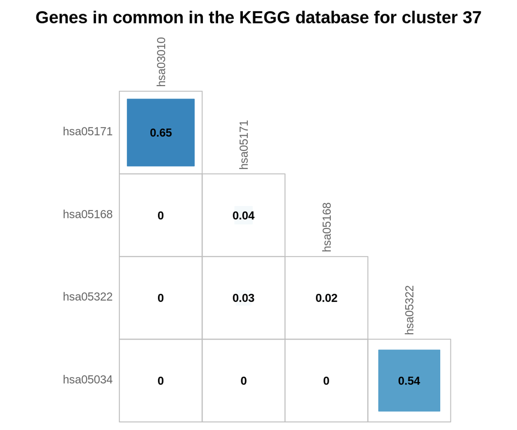

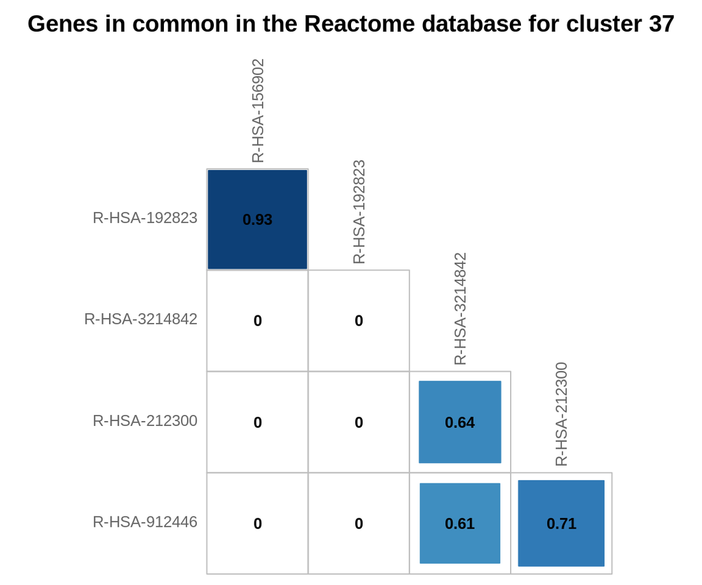

```r
plot_shared_genes_GSEA(selected_modules[1], 5)
```

### ORA enrichment results

```r
print_ORA_top_results(selected_modules[1], 5)
```

GO:

No enriched terms found

DO:

No enriched terms found

DGN:

No enriched terms found

KEGG:

No enriched terms found

Reactome:

|  | ID | Description | p.adjust | qvalue | GeneRatio |
| --- | --- | --- | --- | --- | --- |
| R-HSA-3906995 | R-HSA-3906995 | Diseases associated with O-glycosylation of proteins | 0.006438 | 0.006438 | 5/49 |

## GSEA and ORA top enrichment results for cluster 49

### GSEA enrichment results

```r
print_GSEA_top_results(selected_modules[2], 5)
```

GO:

No enriched terms found

DO:

No enriched terms found

DGN:

No enriched terms found

KEGG:

|  | ID | Description | NES | p.adjust | qvalues |
| --- | --- | --- | --- | --- | --- |
| hsa05322 | hsa05322 | Systemic lupus erythematosus | 2.716896 | 0.0082325 | 0.0013473 |
| hsa03010 | hsa03010 | Ribosome | 2.705384 | 0.0083285 | 0.0013473 |
| hsa05171 | hsa05171 | Coronavirus disease - COVID-19 | 2.439782 | 0.0087722 | 0.0013473 |
| hsa05150 | hsa05150 | Staphylococcus aureus infection | 1.942444 | 0.0471328 | 0.0043787 |
| hsa05034 | hsa05034 | Alcoholism | 1.936419 | 0.0085113 | 0.0013473 |

Reactome:

|  | ID | Description | NES | p.adjust | qvalues |
| --- | --- | --- | --- | --- | --- |
| R-HSA-1799339 | R-HSA-1799339 | SRP-dependent cotranslational protein targeting to membrane | 3.173339 | 0.0320889 | 0.0003274 |
| R-HSA-156902 | R-HSA-156902 | Peptide chain elongation | 3.167809 | 0.0315031 | 0.0003274 |
| R-HSA-5625886 | R-HSA-5625886 | Activated PKN1 stimulates transcription of AR (androgen receptor) regulated genes KLK2 and KLK3 | 3.159001 | 0.0306993 | 0.0003274 |
| R-HSA-192823 | R-HSA-192823 | Viral mRNA Translation | 3.155346 | 0.0315726 | 0.0003274 |
| R-HSA-156842 | R-HSA-156842 | Eukaryotic Translation Elongation | 3.132303 | 0.0316201 | 0.0003274 |

Plots of the results when there are more than 2 terms in common between methods:

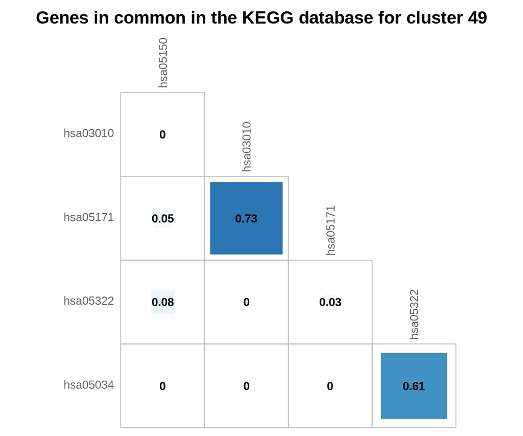

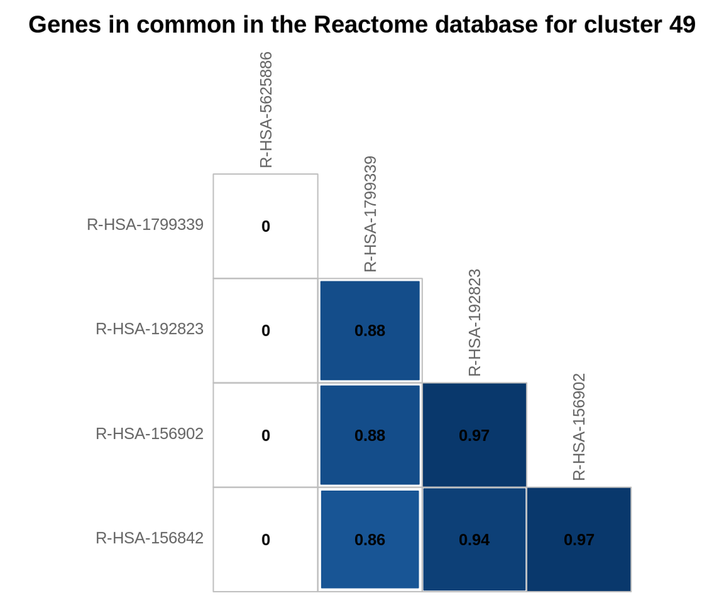

```r
plot_shared_genes_GSEA(selected_modules[2], 5)
```

### ORA enrichment results

```r
print_ORA_top_results(selected_modules[2], 5)
```

GO:

No enriched terms found

DO:

No enriched terms found

DGN:

No enriched terms found

KEGG:

|  | ID | Description | p.adjust | qvalue | GeneRatio |
| --- | --- | --- | --- | --- | --- |
| hsa03013 | hsa03013 | Nucleocytoplasmic transport | 0.0426898 | 0.0410291 | 4/32 |

Reactome:

No enriched terms found